# 2020 HINTS Project

Katirna Alatorre, Katrina Huynh, Jaime Rosas, and Linda Zavala

2026-03-08

# 2020 Health Information National Trends Survey (HINTS) Analysis

Project Objectives: This project analyzes data from the 2020 Health Information National Trends Survey (HINTS). The goal is to examine health behaviors and demographic characteristics.

## HINTS Data Import

```r
hints.data <- read.csv("C:/Users/zlind/Downloads/HINTSData_2020_clean.csv")
```

The following data focuses on the variables:

Age, AvgDrinksPerWeek, WeeklyMinutesModerateExcersice, BMI, QualityCare, BirthGender, smokeStat, and RaceEthn5.

## Statistical Descriptive Analysis

### Age

The average age HINTS participant was approximately 56, the youngest participant was 18 and the oldest participant was 100 years of age. Furthermore, the median age was 58.

```r
summary(hints.data$Age, na.rm=TRUE)
```

```
##    Min. 1st Qu.  Median    Mean 3rd Qu.    Max.
##   18.00   43.00   58.00   55.59   68.00  100.00
```

### BMI

The lowest BMI value among the HINTS participants was 10.90 and the highest was approximately 73.80. The average BMI among participants was 28.61.

```r
summary(hints.data$BMI, na.rm = TRUE)
```

```
##    Min. 1st Qu.  Median    Mean 3rd Qu.    Max.
##   10.90   24.00   27.50   28.61   31.90   73.80
```

```r
var(hints.data$BMI, na.rm = TRUE)
```

```
## [1] 42.75028
```

### Function for Descriptive Statistics

```r
#creating a function to summarize the statisical summaries of the continous variables of intrest

my_summary_func <- function(x) { #defines a function
  list(
    Mean = mean(x),#mean
    SD = sd (x), #standard deviation
    Variance = var(x), #vairance
    Five.Num.Summary = summary(x) #five summary
  )
}

#applying my_summary_function to all continous variables
my_summary_func(hints.data$Age)
```

```
## $Mean
## [1] 55.59117
##
## $SD
## [1] 16.57902
##
## $Variance
## [1] 274.864
##
## $Five.Num.Summary
##    Min. 1st Qu.  Median    Mean 3rd Qu.    Max.
##   18.00   43.00   58.00   55.59   68.00  100.00
```

```r
my_summary_func(hints.data$BMI)
```

```
## $Mean
## [1] 28.60704
##
## $SD
## [1] 6.538369
##
## $Variance
## [1] 42.75028
##
## $Five.Num.Summary
##    Min. 1st Qu.  Median    Mean 3rd Qu.    Max.
##   10.90   24.00   27.50   28.61   31.90   73.80
```

```r
my_summary_func(hints.data$AvgDrinksPerWeek)
```

```
## $Mean
## [1] 3.358035
##
## $SD
## [1] 6.588142
##
## $Variance
## [1] 43.40362
##
## $Five.Num.Summary
##    Min. 1st Qu.  Median    Mean 3rd Qu.    Max.
##   0.000   0.000   0.000   3.358   4.000  70.000
```

```r
my_summary_func(hints.data$WeeklyMinutesModerateExercise)
```

```
## $Mean
## [1] 161.7818
##
## $SD
## [1] 271.1893
##
## $Variance
## [1] 73543.61
##
## $Five.Num.Summary
##    Min. 1st Qu.  Median    Mean 3rd Qu.    Max.
##     0.0     0.0    90.0   161.8   210.0  4620.0
```

## Univariate Visualizations

### Quality of Care

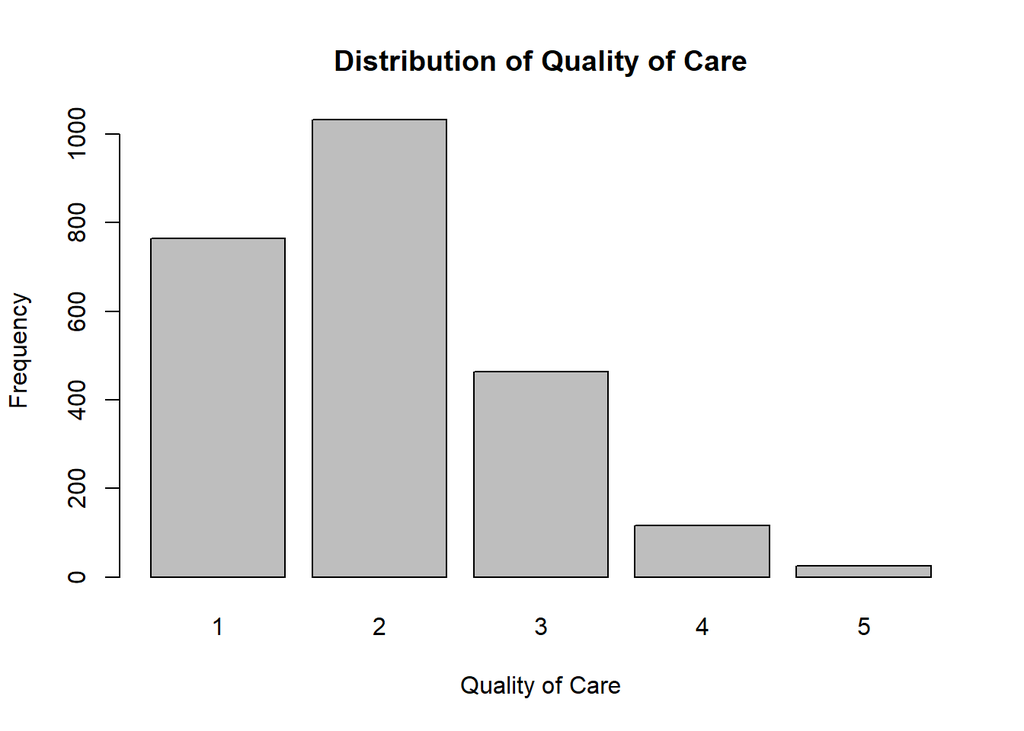

```r
#create bar graph for quality of care distribtion
barplot(table(hints.data$QualityCare), #create table
        main = "Distribution of Quality of Care", #names graph
        xlab = "Quality of Care", #labels x-axis
        ylab = "Frequency") # labels y-axis
```

Key:

1 Excellent

2 Very Good

3 Good

4 Fair

5 Poor

### Race and Ethnicity

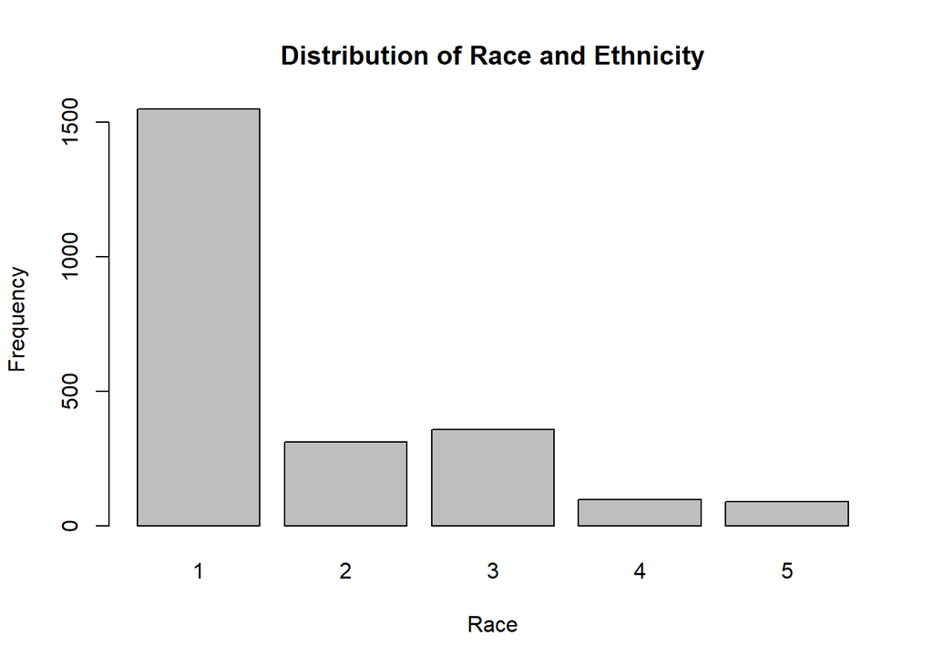

```r
#create bar graph for race and ethnicty
barplot(table (hints.data$RaceEthn5),
        main = "Distribution of Race and Ethnicity", #names graph
        xlab = "Race", #labels x-axis
        ylab = "Frequency") #labels y-axis
```

The bar chart represents the distribution of the Race and Ethnicity of the participants. Each number represents a different option. The majority of the participants were non-Hispanic white.

Key:

1 Non-Hispanic White

2 Non-Hispanic Black or African American

3 Hispanic

4 Non-Hispanic Asian

5 Non-Hispanic Other

### BMI

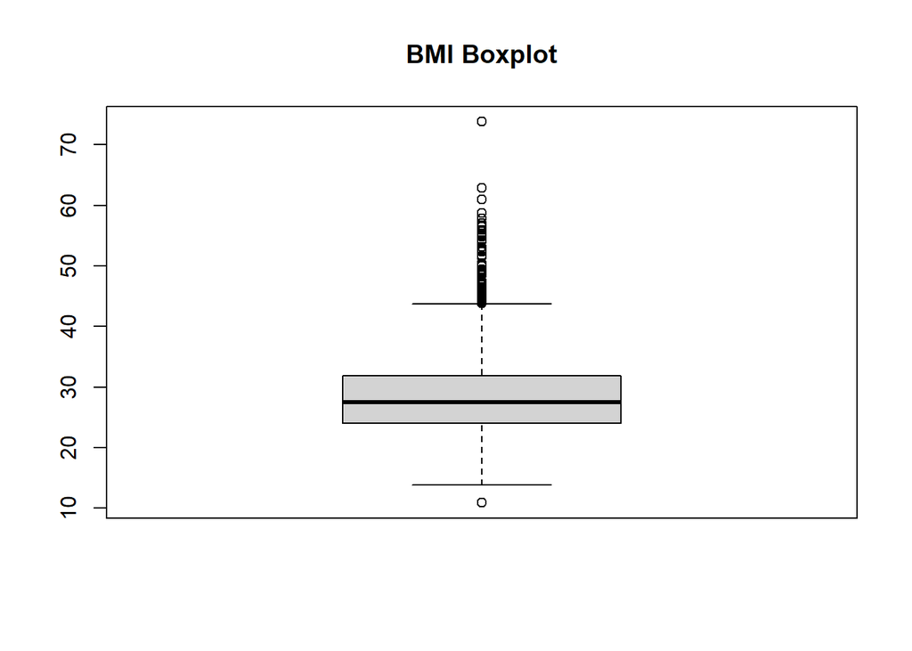

```r
boxplot (hints.data$BMI, main = "BMI Boxplot")
```